# Clinical Subgroup Forest Plot Report

## Report Information

| Protocol | Test Project |
| --- | --- |
| Data Cut-off | 2026-01-30 |
| Data Extract | 2026-02-25 |
| Analysis Set | Intention-To-Treat Analysis Set |

## Review Conditions

> This section records the exact parameters used to generate this report. Any future reproduction using the same `forest_config.yaml` will produce identical results.

| Parameter | Value |
| --- | --- |
| Analysis Endpoint | OS |
| Endpoint Label | Overall Survival |
| Analysis Set | Intention-To-Treat Analysis Set |
| Cancer Type Filter | ALL |
| Cancer Type Label | All Cancer Types |
| Treatment Arm | Drug A |
| Control Arm | Drug B |
| Reference Arm (Cox) | Drug B |
| CI Level | 95% |
| Statistical Model | unstratified |
| Subgroups | Age Years, Sex, Race, ECOG Status |
| Generated At | 2026-08-12 00:02 |

## Dataset Summary

| Description | N |
| --- | --- |
| Total subjects | 300 |
| Drug A | 150 |
| Drug B | 150 |

## Forest Plot

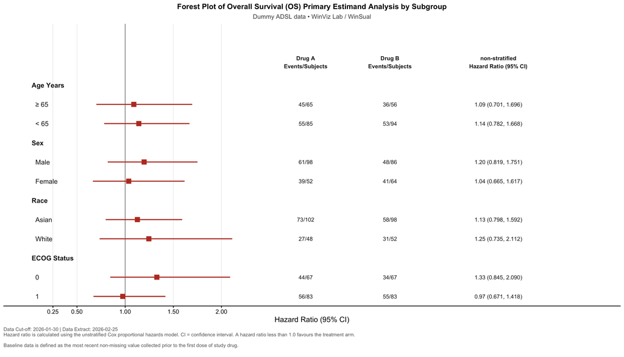

## Interpretation

Subgroups favouring **Drug A** (HR < 1.0): 1.

Subgroups not favouring **Drug A** (HR ≥ 1.0): ≥ 65, < 65, Male, Female, Asian, White, 0.

> **Note:** This interpretation is generated automatically from the data. No formal interaction test was performed in this review document. Statistical significance of subgroup differences should be assessed separately.

## Footnotes

Hazard ratio is calculated using the unstratified Cox proportional hazards model. CI = confidence interval. A hazard ratio less than 1.0 favours the treatment arm.

Baseline data is defined as the most recent non-missing value collected prior to the first dose of study drug.

*Report generated using `forest_config.yaml` — all review conditions are fully preserved above.*